# Time Series Forecasting - Quiz 3 - Solution Notebook

```python
import pandas as pd
import numpy as np
import seaborn as sns
from matplotlib import pyplot as plt
import matplotlib
import statsmodels
```

```python
print('Pandas version:',pd.__version__)
print('Numpy version:',np.__version__)
print('Seaborn version:',sns.__version__)
print('Matplotlib version:',matplotlib.__version__)
print('Statsmodels version:',statsmodels.__version__)
```

```
Pandas version: 1.0.5
Numpy version: 1.19.0
Seaborn version: 0.10.1
Matplotlib version: 3.2.1
Statsmodels version: 0.11.1
```

```python
import os
os.chdir('D:/Academic Operations/DSBA - Python/Online/Time Series Forecasting/Assessments/Quiz 3')
```

# Q1. Read the data as an yearly Time Series and check whether the Time Series data is stationary at $\alpha$ = 0.05 using the Augmented Dickey Fuller (ADF) test.

```python
df = pd.read_csv("GDP_change.csv", parse_dates = True, index_col = 0)
df.head()
```

| Year | GDP |
| --- | --- |
| 1962-01-01 | -0.791615 |
| 1963-01-01 | 3.063226 |
| 1964-01-01 | 1.458597 |
| 1965-01-01 | -10.088720 |
| 1966-01-01 | 2.580441 |

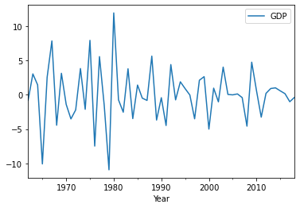

```python
df.plot();
```

```python
from statsmodels.tsa.stattools import adfuller
```

```python
dftest = adfuller(df)
print('DF test statistic is %3.3f' %dftest[0])
print('DF test p-value is' ,dftest[1])
```

```
DF test statistic is -4.894
DF test p-value is 3.5825080252538444e-05
```

We can see that the data is stationary at 95% confidence since the p-value is less than $\alpha$ = 0.05.

# Q2. What is the significant lag after which the ACF and the PACF cut-off at $\alpha$=0.05?

```python
from statsmodels.tsa.api import graphics
```

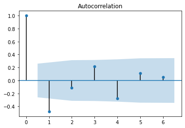

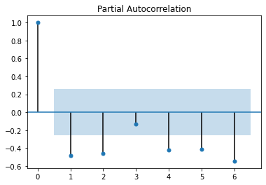

```python
graphics.plot_acf(df,lags=6)
graphics.plot_pacf(df,lags=6);
```

```python
from statsmodels.graphics.tsaplots import plot_acf,plot_pacf
```

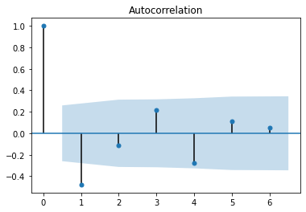

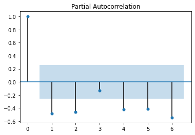

```python
plot_acf(df,lags=6)
plot_pacf(df,lags=6);
```

We see that the ACF cuts-off at lag 2. The ACF line is below the 95% confidence interval line. **The significant lag after which the ACF cuts-off is 1**.

We see that the PACF cuts-off at lag 3. The PACF line is below the 95% confidence interval line. **The significant lag after which the PACF cuts-off is 2**.

# Q3. Build two ARIMA models with the following parameters and comment on the AIC.

# Model 1 - ARIMA (2,0,3)

# Model 2 - ARIMA (3,0,5)

```python
import statsmodels.api as sm

## ARIMA(2, 0, 3)
model_1 = sm.tsa.statespace.SARIMAX(df,
                                order=(2,0,3),
                                seasonal_order=None,
                                enforce_stationarity=False,
                                enforce_invertibility=False)
results_ARIMA_1 = model_1.fit()
print(results_ARIMA_1.summary())
```

```
                               SARIMAX Results
==============================================================================
Dep. Variable:                    GDP   No. Observations:                   57
Model:               SARIMAX(2, 0, 3)   Log Likelihood                -127.327
Date:                Fri, 04 Sep 2020   AIC                            266.655
Time:                        11:49:40   BIC                            278.476
Sample:                    01-01-1962   HQIC                           271.201
                         - 01-01-2018
Covariance Type:                  opg
==============================================================================
                 coef    std err          z      P>|z|      [0.025      0.975]
------------------------------------------------------------------------------
ar.L1         -0.5124      0.255     -2.007      0.045      -1.013      -0.012
ar.L2         -0.5552      0.189     -2.945      0.003      -0.925      -0.186
ma.L1         -0.7358      0.324     -2.273      0.023      -1.370      -0.101
ma.L2          0.0831      0.313      0.266      0.791      -0.530       0.696
ma.L3         -0.6408      0.281     -2.280      0.023      -1.192      -0.090
sigma2         5.3060      1.139      4.660      0.000       3.074       7.538
===================================================================================
Ljung-Box (Q):                       34.77   Jarque-Bera (JB):                19.45
Prob(Q):                              0.70   Prob(JB):                         0.00
Heteroskedasticity (H):               0.26   Skew:                            -0.85
Prob(H) (two-sided):                  0.01   Kurtosis:                         5.43
===================================================================================

Warnings:
[1] Covariance matrix calculated using the outer product of gradients (complex-step).
```

```python
## ARIMA(3, 0, 5)
model_2 = sm.tsa.statespace.SARIMAX(df,
                                order=(3,0,5),
                                seasonal_order=None,
                                enforce_stationarity=False,
                                enforce_invertibility=False)
results_ARIMA_2 = model_2.fit()
print(results_ARIMA_2.summary())
```

```
                               SARIMAX Results
==============================================================================
Dep. Variable:                    GDP   No. Observations:                   57
Model:               SARIMAX(3, 0, 5)   Log Likelihood                -116.670
Date:                Fri, 04 Sep 2020   AIC                            251.339
Time:                        11:49:40   BIC                            268.726
Sample:                    01-01-1962   HQIC                           257.983
                         - 01-01-2018
Covariance Type:                  opg
==============================================================================
                 coef    std err          z      P>|z|      [0.025      0.975]
------------------------------------------------------------------------------
ar.L1         -0.8388      0.275     -3.049      0.002      -1.378      -0.300
ar.L2         -0.2861      0.341     -0.839      0.402      -0.954       0.382
ar.L3         -0.0526      0.223     -0.235      0.814      -0.490       0.385
ma.L1         -0.2132    733.493     -0.000      1.000   -1437.832    1437.406
ma.L2         -0.7661    889.861     -0.001      0.999   -1744.861    1743.328
ma.L3         -0.0668    327.999     -0.000      1.000    -642.932     642.799
ma.L4         -0.0758    377.029     -0.000      1.000    -739.040     738.888
ma.L5          0.4381    321.397      0.001      0.999    -629.488     630.364
sigma2         5.2124   3823.254      0.001      0.999   -7488.227    7498.652
===================================================================================
Ljung-Box (Q):                       34.42   Jarque-Bera (JB):                 2.57
Prob(Q):                              0.72   Prob(JB):                         0.28
Heteroskedasticity (H):               0.27   Skew:                            -0.55
Prob(H) (two-sided):                  0.01   Kurtosis:                         2.93
===================================================================================

Warnings:
[1] Covariance matrix calculated using the outer product of gradients (complex-step).
```

# Q4. The following is a diagnostics plot of which of the models mentioned in the last question?

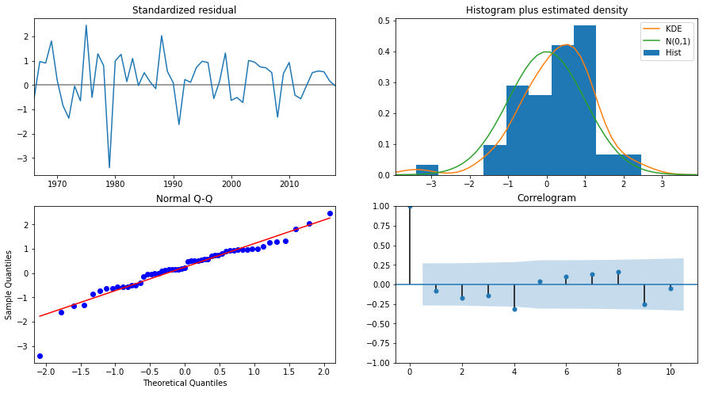

```python
results_ARIMA_1.plot_diagnostics(figsize=(15,8));
```

The above is a diagnostics plot of model 1.